# PS 812

Section 8: Hypothesis Tests and Power

John Hicks

Dept. of Political Science, UW-Madison

2026-10-30

# Today

## Today

**1. Hypothesis testing review**

Pretend the null is true. Calibrate the test so we’re wrong 5% of the time

**2. The variance of a difference in means**

**3. Power, analytically**

Imagine the effect is this big. How often do we reject?

**4. Power, by simulation**

## A survey experiment

Respondents read a short news story:

> The United States is engaged in trade negotiations with the European Union. After the talks stalled, the United States **[launched economic sanctions / decided to take no action]**.
- Then: *“How much do you approve of the way the U.S. government handled this situation?”* (0–100 slider)
- **Treatment**: sanctions. **Control**: no action
- A **pilot** with 200 respondents, 100 per condition (the data are made up)
- Today’s question: **how big should the real study be?**

## The pilot

```r
pilot <- read_csv("data/sanctions_pilot.csv")

pilot |>
  group_by(condition) |>
  summarise(n = n(), mean = mean(support), sd = sd(support))
```

```
# A tibble: 2 x 4
  condition     n  mean    sd
  <chr>     <int> <dbl> <dbl>
1 No action   100  45.5  17.2
2 Sanctions   100  50.4  21.6
```

Same steps as the ANES example in lecture, for a difference in means:

```r
pilot_test <- pilot |>
  summarise(est   = mean(support[treat == 1]) - mean(support[treat == 0]),
            se    = sqrt(var(support[treat == 1]) / sum(treat == 1) +
                         var(support[treat == 0]) / sum(treat == 0)),   # derived below
            t     = est / se,
            p     = 2 * pnorm(-abs(t)),
            lower = est - qnorm(0.975) * se,
            upper = est + qnorm(0.975) * se)
```

- Sanctions raise approval by about 4.9 points, with $p =$ 0.074. The 95% CI includes 0
- We fail to reject at 0.05. Does that mean sanctions don’t matter?

# Hypothesis testing

## Framework

1. **Null and alternative**: $H_0: \tau = 0$, $H_a: \tau \neq 0$
2. **Test statistic**: $T = \dfrac{\hat\tau - 0}{\widehat{SE}(\hat\tau)}$
3. **Type I error rate**: $\alpha = 0.05$
4. **Null distribution**: $T \overset{a}{\sim} \mathcal{N}(0, 1)$ (CLT, plus Slutsky because we plug in $\widehat{SE}$)
5. **Rejection region**: $|T| > z_{1 - \alpha/2} = 1.96$
6. **Compute** $T$ in the pilot: 1.78
7. **Decide**: it’s not in the rejection region, so we **fail to reject** $H_0$
- Same as checking whether 0 is in the 95% CI: a CI is the set of nulls we’d fail to reject

## The rejection region

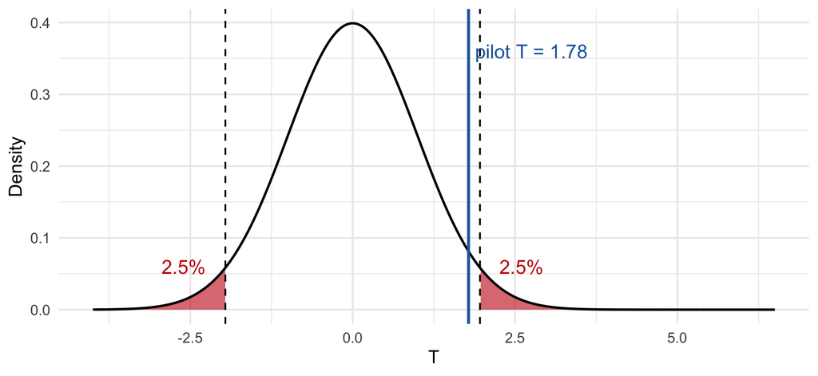

- Red: the **rejection region**. Under $H_0$, $T$ lands there 5% of the time
- The pilot’s $T$ falls just short

## Two ways to be wrong

|  | $H_0$ **true** | $H_0$ **false** |
| --- | --- | --- |
| **Retain** $H_0$ | Correct | **Type II** error (false negative) |
| **Reject** $H_0$ | **Type I** error (false positive) | Correct |

- We **choose** $\alpha$, the **level** or **size** of the test. It’s calibrated so that **when the null is true** we reject 5% of the time
- **Power** $= 1 - P(\text{false negative})$. We **don’t** choose it. It depends on the **true effect**, the **noise**, and the **sample size**
- So power is always “power to detect an effect of size $\tau$”. We have to say how big an effect we care about

## Calibration: imagine the null is true

A hypothetical difference in means. We pick everything, including the truth:

```r
sim_t <- function(n1, n0, tau, sd1, sd0) {
  y1 <- rnorm(n1, mean = tau, sd = sd1)
  y0 <- rnorm(n0, mean = 0,   sd = sd0)
  (mean(y1) - mean(y0)) / sqrt(var(y1) / n1 + var(y0) / n0)
}

t_null <- replicate(5000, sim_t(n1 = 100, n0 = 100, tau = 0, sd1 = 22, sd0 = 17))
mean(abs(t_null) > qnorm(0.975))
```

```
[1] 0.0588
```

- 5,000 pilots in a world where sanctions do **nothing**
- We reject about 5% of the time.

## Calibration: imagine the null is true

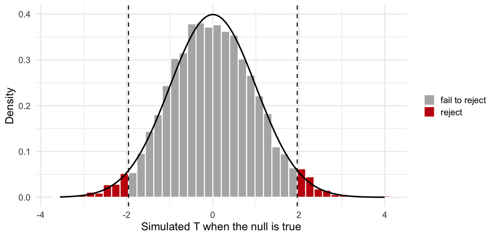

- The simulated $T$’s follow the $\mathcal{N}(0, 1)$ curve. The red bars are the Type I errors

# The variance of a difference in means

## The setup

$$\hat\tau = \bar Y_1 - \bar Y_0$$

- $n_1$ treated respondents, outcomes i.i.d. with variance $\sigma_1^2$
- $n_0$ control respondents, outcomes i.i.d. with variance $\sigma_0^2$
- Every $SE$ in today’s power calculations comes from $\text{Var}(\hat\tau)$. So let’s derive it

## Step 1: one mean

$$\begin{aligned}
\text{Var}(\bar Y_1) &= \text{Var}\left(\frac{1}{n_1} \sum_{i=1}^{n_1} Y_i\right) \\
&= \frac{1}{n_1^2}\, \text{Var}\left(\sum_{i=1}^{n_1} Y_i\right) &&\text{constants come out squared} \\
&= \frac{1}{n_1^2} \sum_{i=1}^{n_1} \text{Var}(Y_i) &&\text{independent: no covariance terms} \\
&= \frac{n_1 \sigma_1^2}{n_1^2} = \frac{\sigma_1^2}{n_1} &&\text{identically distributed}
\end{aligned}$$

## Step 2: the difference

$$\begin{aligned}
\text{Var}(\bar Y_1 - \bar Y_0) &= \text{Var}(\bar Y_1) + \text{Var}(\bar Y_0) - 2\,\text{Cov}(\bar Y_1, \bar Y_0) \\
&= \frac{\sigma_1^2}{n_1} + \frac{\sigma_0^2}{n_0}
\end{aligned}$$

- $\text{Cov}(\bar Y_1, \bar Y_0) = 0$: different respondents, independent draws
- The minus becomes a **plus**. Subtracting two noisy things adds their noise
- Estimate it by plugging in the sample variances: $\widehat{SE} = \sqrt{s_1^2 / n_1 + s_0^2 / n_0}$

## Check: by hand vs. `lm_robust()`

```r
fit <- lm_robust(support ~ treat, data = pilot)

c(by_hand = pilot_test$se, lm_robust = fit$std.error[["treat"]])
```

```
  by_hand lm_robust
 2.763414  2.763414
```

```r
c(by_hand = pilot_test$p,  lm_robust = fit$p.value[["treat"]])
```

```
   by_hand  lm_robust
0.07441956 0.07595098
```

- `lm_robust()`’s default SE (HC2) is exactly this formula
- Its p-value is slightly larger because it uses a $t$ distribution instead of the normal (the small-sample correction from lecture)

# Power

## Imagine the effect is this big

If the true effect is $\tau$, then $\hat\tau \approx \mathcal{N}(\tau, SE^2)$, so

$$T = \frac{\hat\tau}{SE} \approx \mathcal{N}\left(\frac{\tau}{SE},\ 1\right)$$

- The **same rejection region**: we calibrated it under the null, and we don’t move it
- A **different distribution** for $T$: shifted right by $\tau / SE$
- Power = the share of this shifted distribution that lands in the rejection region

## Imagine the effect is this big

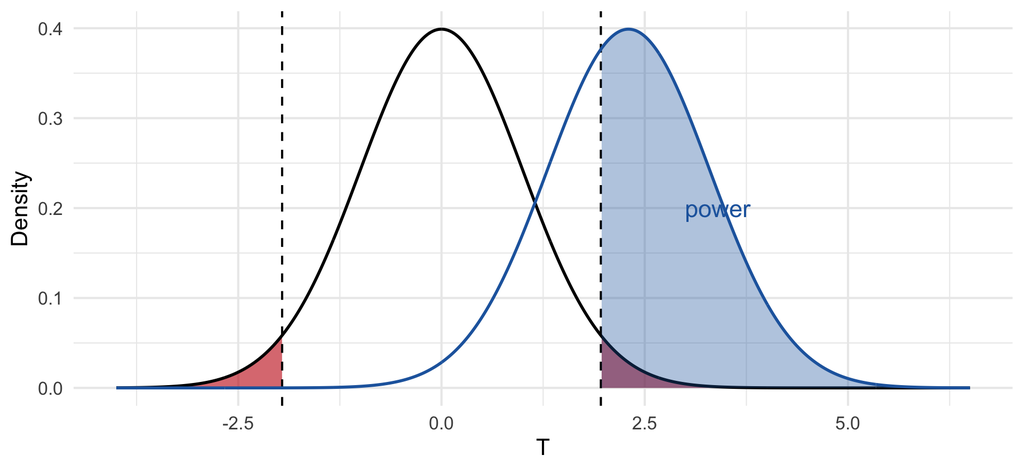

- Black: where $T$ falls if the null is true. Red area = $\alpha$
- Blue: where $T$ falls if $\tau / SE = 2.3$. Blue area = power, here 0.63

## The formula

$$\text{Power} = P(T > z) + P(T < -z) = \Phi\left(\frac{\tau}{SE} - z\right) + \Phi\left(-\frac{\tau}{SE} - z\right), \qquad z = z_{1-\alpha/2}$$

- $\Phi$ is the standard normal CDF (`pnorm()`), and $z_{1-\alpha/2} = \Phi^{-1}(1 - \alpha/2)$ (`qnorm()`), as in lecture
- The second term is tiny unless $\tau$ is near 0, so $\text{Power} \approx \Phi(\tau / SE - 1.96)$
- Everything runs through $\tau / SE$: **the effect measured in standard errors**

```r
power_dim <- function(tau, sd1, sd0, n1, n0, alpha = 0.05) {
  se <- sqrt(sd1^2 / n1 + sd0^2 / n0)
  z  <- qnorm(1 - alpha / 2)
  pnorm(tau / se - z) + pnorm(-tau / se - z)
}

power_dim(tau = 5, sd1 = 22, sd0 = 17, n1 = 100, n0 = 100)
```

```
[1] 0.4359003
```

- If sanctions really raise approval by 5 points, the pilot had a 44% chance of rejecting. Failing to reject tells us very little: an **uninformative** null, in lecture’s terms
- And with power this low, the pilots that *do* reject overstate the effect (the significance filter)

## Check: imagine the effect is 5 points

Same `sim_t()` as before, but now the truth is $\tau = 5$:

```r
t_alt <- replicate(5000, sim_t(n1 = 100, n0 = 100, tau = 5, sd1 = 22, sd0 = 17))
mean(abs(t_alt) > qnorm(0.975))
```

```
[1] 0.4404
```

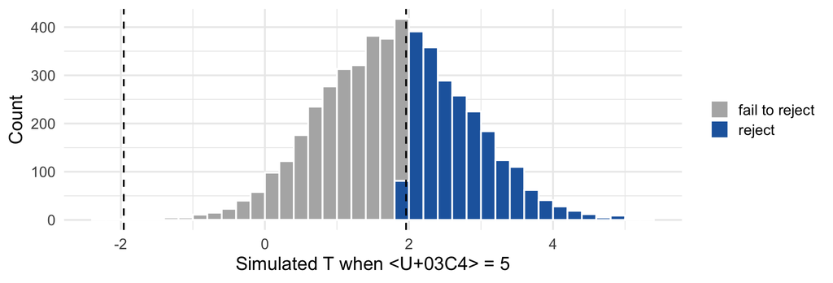

- The formula and the simulation agree. Everything grey is a **Type II error**

## Effects in SD units

- “5 points” means little without knowing the noise. Standardize: $\delta = \tau / \sigma$
- With equal variances and an even split, $SE = 2\sigma / \sqrt n$, so

$$\frac{\tau}{SE} = \frac{\tau}{2\sigma / \sqrt n} = \frac{\delta \sqrt n}{2}
\qquad\Rightarrow\qquad
\text{Power} \approx \Phi\left(\frac{\delta \sqrt n}{2} - 1.96\right)$$

- Power depends only on $\delta$ and $n$. The units of $Y$ drop out

## Power curves

```r
curves <- expand_grid(n = seq(20, 3000, by = 10), delta = c(0.1, 0.2, 0.3, 0.5)) |>
  mutate(power = power_dim(tau = delta, sd1 = 1, sd0 = 1, n1 = n / 2, n0 = n / 2))

ggplot(curves, aes(x = n, y = power, colour = factor(delta))) +
  geom_line(linewidth = 1.2) +
  geom_hline(yintercept = 0.8, linetype = "dashed") +
  labs(x = "Total n", y = "Power", colour = "δ (SDs)")
```

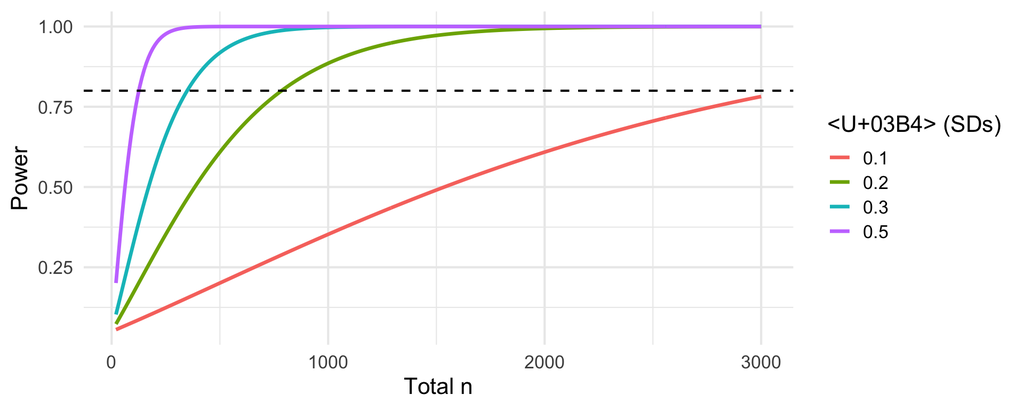

- With `sd1 = sd0 = 1`, `tau` **is** $\delta$
- Halve the effect and you need four times the sample

## Backing out $n$

For 80% power, $\tau / SE$ has to put 80% of the blue curve past 1.96:

$$\frac{\tau}{SE} = z_{0.975} + z_{0.80} = 1.96 + 0.84 = 2.80$$

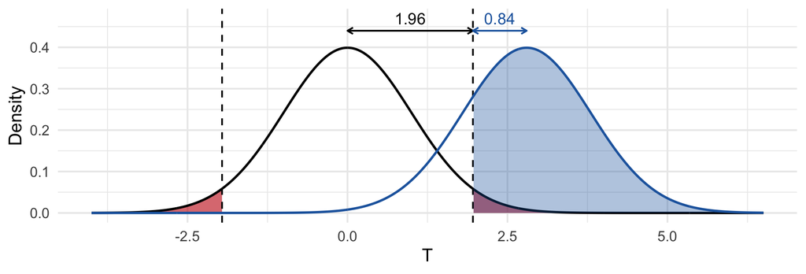

- Set $\delta \sqrt n / 2 = 2.8$ and solve: $n = (5.6 / \delta)^2 \approx 31.4 / \delta^2$

| $\delta$ | 0.5 | 0.3 | 0.2 | 0.1 |
| --- | --- | --- | --- | --- |
| $n$ for 80% power | 126 | 349 | 784 | 3,136 |

## The minimum detectable effect

Flip it around. Fix $n$ (the budget) and solve for $\tau$:

$$\text{MDE} = 2.8 \times SE$$

```r
se_1000 <- sqrt(22^2 / 500 + 17^2 / 500)
2.8 * se_1000
```

```
[1] 3.481471
```

- With 1,000 respondents split evenly and the pilot’s SDs, we’d detect a 3.5-point effect 80% of the timeI

## Where do the $\sigma$’s come from?

- A pilot (ours), past studies with the same outcome, or a **worst case**
- Binary outcomes have one: if $Y \in \{0, 1\}$ then $\sigma^2 = p(1 - p) \le 1/4$
- So with an even split, $SE \le \sqrt{\frac{1/4}{n/2} + \frac{1/4}{n/2}} = \frac{1}{\sqrt n}$
- $n = 1{,}000$: $SE \le 3.2$ points, MDE $\le 8.9$ percentage points. A good back-of-the-envelope
- But it’s conservative. In the pilot, `approve` (support > 50) has

```r
pilot |> group_by(condition) |> summarise(p = mean(approve), var = p * (1 - p))
```

```
# A tibble: 2 x 3
  condition     p   var
  <chr>     <dbl> <dbl>
1 No action  0.33 0.221
2 Sanctions  0.5  0.25
```

- Close to the worst case here because $p$ is near 0.5. With $p = 0.1$, $\sigma^2 = 0.09$, not $0.25$

# Unequal variances

## Who should get more respondents?

- In the pilot the treated group is noisier: SD 21.6 vs. 17.2
- Why? Sanctions **split** respondents. Republicans approve more, Democrats barely move. Different effects add variance to the treated group
- With $n$ fixed, an even split isn’t the best we can do. Choose $n_1$ to minimize

$$\text{Var}(\hat\tau) = \frac{\sigma_1^2}{n_1} + \frac{\sigma_0^2}{n - n_1}$$

## The optimal split

Take the derivative with respect to $n_1$ and set it to zero:

$$-\frac{\sigma_1^2}{n_1^2} + \frac{\sigma_0^2}{n_0^2} = 0
\qquad\Rightarrow\qquad
\frac{n_1}{n_0} = \frac{\sigma_1}{\sigma_0}$$

- **Over-sample the noisier group**, in proportion to its **SD** (not its variance)
- Share treated: $\sigma_1 / (\sigma_1 + \sigma_0)$
- Same logic as allocating a survey across subgroups: spend respondents where the noise is

## The optimal split in the pilot

```r
sd1 <- 22; sd0 <- 17
split <- tibble(share = seq(0.2, 0.8, by = 0.01)) |>
  mutate(se = sqrt(sd1^2 / (1000 * share) + sd0^2 / (1000 * (1 - share))))

ggplot(split, aes(x = share, y = se)) +
  geom_line(linewidth = 1.2) +
  geom_vline(xintercept = c(0.5, sd1 / (sd1 + sd0)), linetype = c("dashed", "solid"),
             colour = c("grey40", uw_red)) +
  labs(x = "Share of 1,000 respondents treated", y = "SE of the difference in means")
```

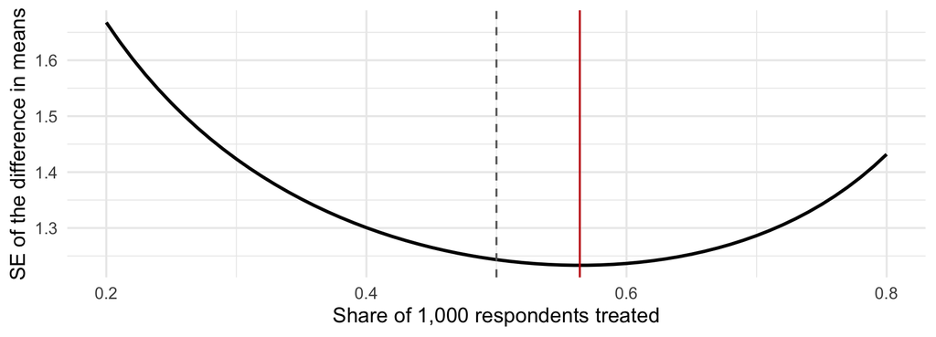

- Optimum at 0.56 treated. But the curve is **flat** near the bottom: the SE falls from 1.24 to 1.23
- Big gains only when the SDs are very different. If $\sigma_1 = 3\sigma_0$, the optimum is 75% treated and the SE is 11% smaller than with an even split

# Simulation

## When you forget the formula

1. **Write down a world**: $n$, the true effect, the noise, how treatment is assigned
2. **Generate** a dataset from it
3. **Analyze** it the way you actually will: estimate, SE, test
4. **Repeat** many times
5. **Power** = the share of datasets where you reject
- We already did this with `sim_t()`
- It works for **any** design and **any** estimator. The formula only covers the simple case

## A world that looks like the pilot

```r
make_world <- function(n) {
  tibble(rep = rbinom(n, 1, 0.5)) |>
    mutate(y0    = 35 + 20 * rep + rnorm(n, 0, 14),   # control: Republicans start higher
           tau_i = 2 + 6 * rep + rnorm(n, 0, 12),     # effects: Republicans move more
           y1    = y0 + tau_i)
}
```

- Both potential outcomes for everyone. We can do that because we made them up
- The average effect is $2 + 6 \times 0.5 = 5$ points. The SDs come from a very big world:

```r
big <- make_world(1e6)
c(ate = mean(big$tau_i), sd1 = sd(big$y1), sd0 = sd(big$y0))
```

```
      ate       sd1       sd0
 5.003199 22.564469 17.205845
```

## Assign, analyze, repeat

```r
assign_complete <- function(d) mutate(d, treat = sample(rep(0:1, length.out = n())))

dim_t <- function(d) {
  y1 <- d$y[d$treat == 1]
  y0 <- d$y[d$treat == 0]
  (mean(y1) - mean(y0)) / sqrt(var(y1) / length(y1) + var(y0) / length(y0))
}

sim_power <- function(n, assign = assign_complete, test = dim_t, reps = 1000) {
  t <- replicate(reps, {
    make_world(n) |>
      assign() |>
      mutate(y = if_else(treat == 1, y1, y0)) |>   # reveal one potential outcome
      test()
  })
  mean(abs(t) > qnorm(0.975))
}
```

```r
sim_power(n = 500)
```

```
[1] 0.81
```

```r
power_dim(tau = 5, sd1 = sd(big$y1), sd0 = sd(big$y0), n1 = 250, n0 = 250)
```

```
[1] 0.7956238
```

## Complication: block on party

Party predicts approval. So randomize **within** party, and estimate within party:

```r
assign_block <- function(d) {
  d |> group_by(rep) |> mutate(treat = sample(rep(0:1, length.out = n()))) |> ungroup()
}

block_t <- function(d) {
  b <- d |>
    group_by(rep) |>
    summarise(w   = n() / nrow(d),
              est = mean(y[treat == 1]) - mean(y[treat == 0]),
              v   = var(y[treat == 1]) / sum(treat) + var(y[treat == 0]) / sum(1 - treat))
  sum(b$w * b$est) / sqrt(sum(b$w^2 * b$v))
}
```

- The estimate: a weighted average of the two within-party differences in means
- The variance: each block’s $\sigma_1^2 / n_1 + \sigma_0^2 / n_0$, weighted by $w_b^2$. The same derivation, once per block

## Complication: block on party

```r
c(complete = sim_power(n = 400),
  blocked  = sim_power(n = 400, assign = assign_block, test = block_t))
```

```
complete  blocked
   0.696    0.862
```

- Same $n$, more power: blocking removes the party differences from the noise
- The formula on the earlier slide doesn’t know about blocks. The simulation does, because we analyzed the data the way we’d really analyze it

## Recap

- **Testing**: assume the null, calibrate the rejection region so Type I errors happen $\alpha$ of the time
- **Variance of a difference in means**: $\sigma_1^2 / n_1 + \sigma_0^2 / n_0$. Variances add, covariance is zero
- **Power**: shift the distribution of $T$ by $\tau / SE$ and see how much lands in the rejection region
- **80% power** needs $\tau / SE = 2.8$. MDE $= 2.8 \times SE$. In SD units, $n \approx 31.4 / \delta^2$
- **Unequal variances**: $n_1 / n_0 = \sigma_1 / \sigma_0$. Over-sample the noisier group

## **Simulation**: write down a world, generate, analyze, repeat.

# Exercise

## Exercise

Open `ps812_section8_exercise.qmd`.

- Part 1: testing and the variance of a difference in means
- Part 2: power by formula
- Part 3: power by simulation